# WCARO output 1 use case 1

Akvo - data science

11/9/2021

# 1 Introduction

There seem to be large discrepancies between the number of people that are reported having access to water, when different methodologies for estimating water access are used. In this overview three ways of estimating water access in the region Kambia will be shown to demonstrate this difference. The region was chosen because in a country comparison it showed large differences when choosing a different methodology.

# 2 Methodology

Country governments are required to report their progress on all the three key indicators of SDG and grade themselves in the JMP ladder. It is relatively easier to measure coverage by recording the number of water points that are installed, however one requirement of JMP to reach the level “basic” is that the water can be fetched in 30 minutes. This means a family should be able to make a round trip, including queuing, within 30 minutes. The general measurement of water coverage does not take population density taken into account. Countries face challenges in recording and updating their data either due to lack of resources or capacity to collect information about SDG. With this example we want to show the differences in coverage when accounting for population density.

## 2.1 Example 1: Coverage based on sphere guidelines

The following table shows the water points in the district Kambia at time of the 2016 water point mapping. The coverage is determined using the Sphere guidelines, which are guidelines to determine the number of people a specific type of water point can be expected serve, if it functions well. There are 4 categories in this guideline, mainly: “tap”, “hand pump”, “open hand well” and “mechanized well”.

| ADM2 | Number of water points | Possible coverage (nr of people) |
| --- | --- | --- |
| Kambia | 750 | 291950 |

As you can see from table 1 Kambia has 750 water points that have the ability to cover about 0.29 million people. Of these water points 686 are “improved”, which that have the ability to cover 0.27 million people, see table 2.

| ADM2 | sdg_improved_source | Number of water points | Possible coverage (nr of people) |
| --- | --- | --- | --- |
| Kambia | improved | 686 | 272450 |
| Kambia | unimproved | 64 | 19500 |

Table 3 shows that 750 water point 433 were functional at time of the data collection, and in table 4 you can see out of the 433, 399 were classified as “improved”.

| ADM2 | Functionality | Number of water points | Possible coverage (nr of people) |
| --- | --- | --- | --- |
| Kambia | No - Broken down | 300 | 119600 |
| Kambia | No - Still under construction | 15 | 7100 |
| Kambia | No - Under rehabilitation | 2 | 400 |
| Kambia | Yes - But damaged | 73 | 28150 |
| Kambia | Yes – Functional (and in use) | 336 | 127750 |
| Kambia | Yes – Functional (but not in use) | 24 | 8950 |

| Functionality | improved | unimproved |
| --- | --- | --- |
| Functional | 399 | 34 |
| Not functional | 287 | 30 |

Based on a national inventory in 2016, there were 355469 people living in Kambia in 2016, and based on projections this would have grown to 375191 by 2018. If we were simply to combine the population with the possible coverage, in Kambia 82% of the population is served by the water from the water points. When combining that with the type of water point 77% of the population in Kambia is served by improved water points, see table 5.

| ADM2 | sdg_improved_source | Functionality | Percentage of the population served (%) | csum |
| --- | --- | --- | --- | --- |
| Kambia | improved | Functional | 43 | 43 |
| Kambia | improved | Not functional | 33 | 76 |
| Kambia | unimproved | Functional | 3 | 3 |
| Kambia | unimproved | Not functional | 2 | 5 |

The following graph summarizes the results from above, showing the importance of including information about the water source type and the functionality status when determining water point access.

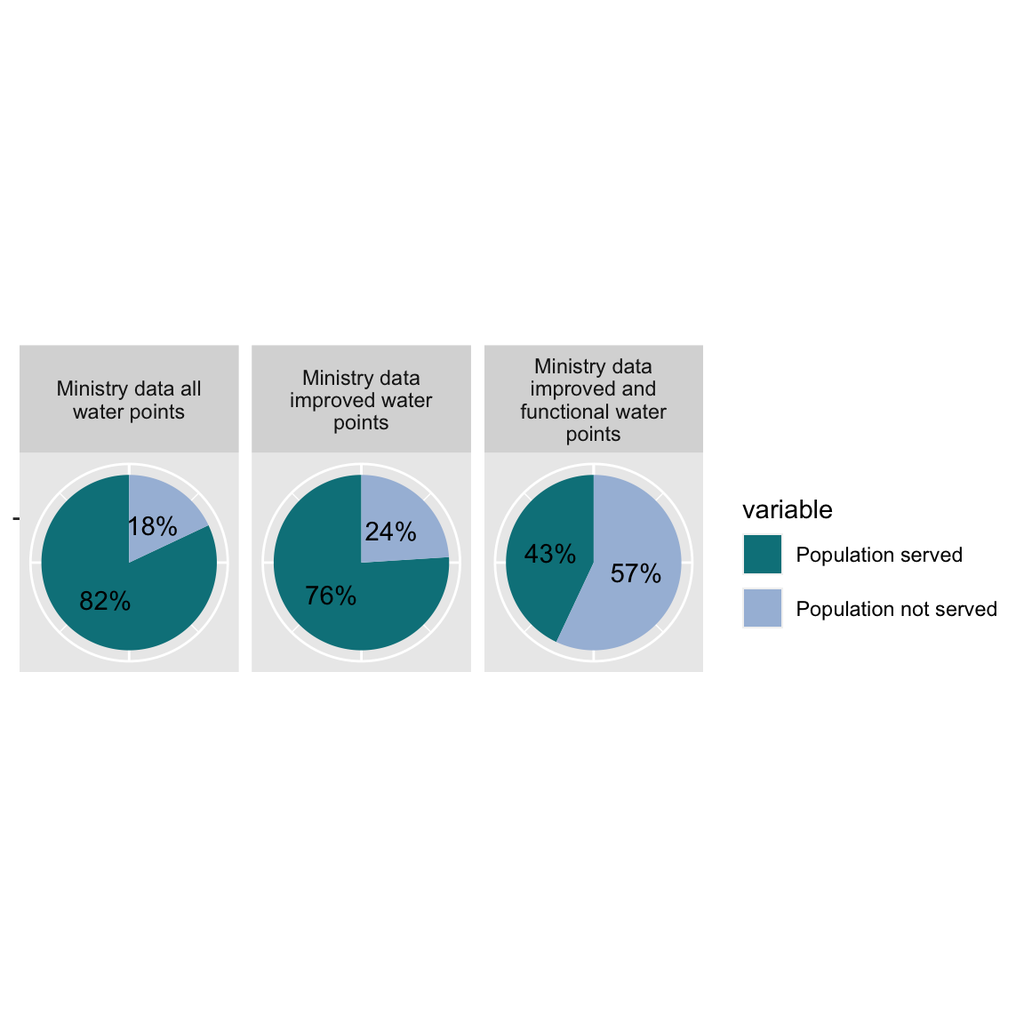

Figure 1: Estimated basic water coverage

This shows that only looking at the possible coverage does not tell the complete story of water supply. Adding current population numbers is critical for identifying vulnerable areas.

Kambia is about 3000 squared kilometers and is estimated to have about 800 villages. When you take into account the requirement of the JMP that water should be collectible within a 30 minute round trip, it is important to know if the water points are dispersed is a way that fits the population density.

The map below shows the location of the different water points in Kambia with the functionality status. The highest concentration of water points seems to be in the middle, and more to the south, and the lowest concentration is in the outer points of the district. Along the eastern boarder there seem to be quite some not functional water points.

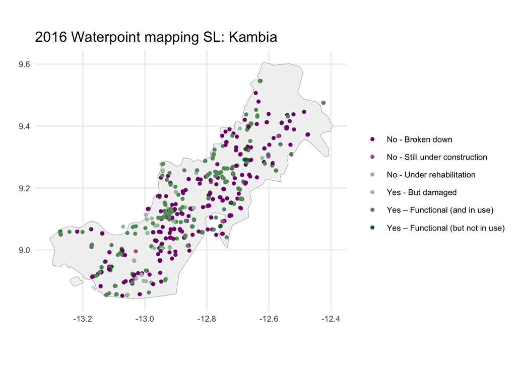

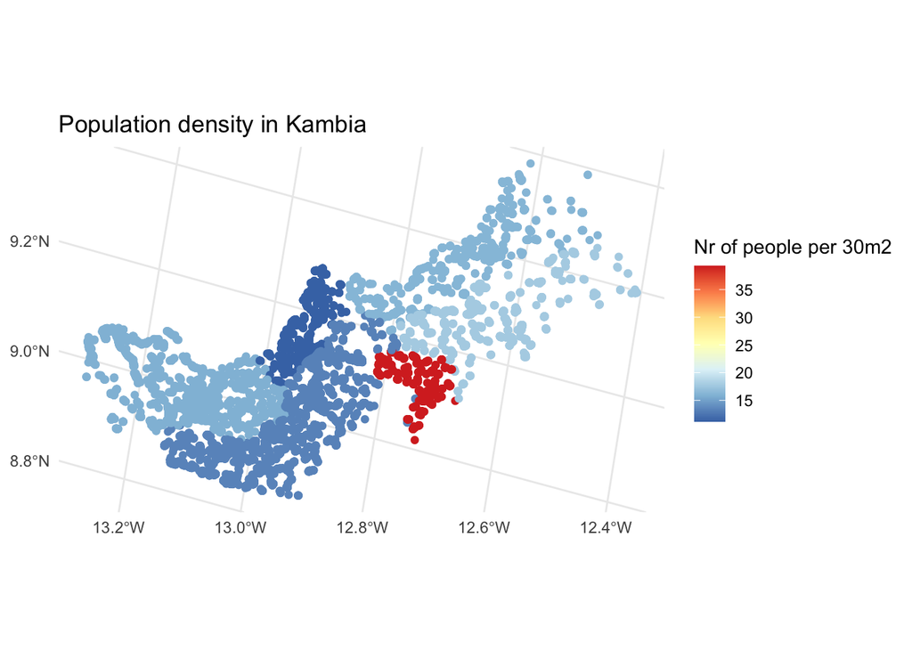

If we want to see how many people live close enough to the water points for the water supply to be considered “basic” water service level, we need to combine the population density data with the water point locations. By taking an area around the water point and determining how many people live within that area, we can first determine the population that is close enough to the water point. Next, we will compare the amount of people to the amount of people the water point can serve based on the sphere guidelines. By looking at the intersection and comparing that to the total population we can determine the percentage of the population actually served. Below we will follow these steps one by one.

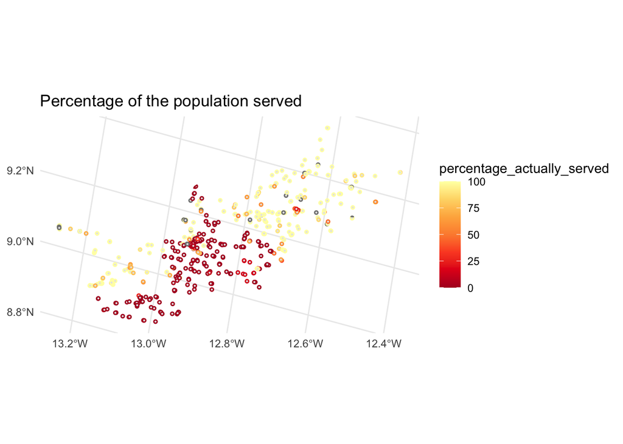

```r
# Convert the water point geolocation to geometry, set the crs to EPSG:4326 (lat/long), and transform to EPSG:3035
wp_2016_sf <- st_as_sf(
  wp_2016_sub,
  coords = c( "Longitude", "Latitude"),
  crs = 4326) %>%
  st_transform(3035)

# Create a buffer of a 500m radius
wp_2016_circles <- st_buffer(wp_2016_sf, dist = 500)

# Make sure the shape file has the same crs
sl.shape <- sl.shape %>% st_set_crs(4326) %>%
  st_transform(3035)

# Intersect water point circles with the shape file to account for overlapping water points
wp_2016_int_circles <- st_intersection(sl.shape, wp_2016_circles)

# Make sure the population data has the same crs
pnts_sf <- st_as_sf(fb_pop_sl,
                    coords = c( "Lon", "Lat"),
                    crs = 4326) %>%
  st_transform(3035)

# Identify the population that falls within the water point radius
kept_points_with_ID <- st_intersection(wp_2016_int_circles, pnts_sf)

# Drop the geometry variable (for analysis speed) and remove possible duplicate entries
kept_points_with_ID_no_geometry <- kept_points_with_ID %>%
  st_drop_geometry() %>%
  select(Water.point.Name, ADM2, sdg_improved_source, sphere_nr_people, ID.1, Population) %>%
  mutate(Population = as.numeric(Population)) %>%
  unique()

# Identify population squares that fall within reach of multiple water points -> make sure they are not counted multiple times
duplicate_pop_density <- kept_points_with_ID_no_geometry %>%
  group_by(ID.1) %>%
  summarise(count=n())

# divide population density number by the amount it has been counted to spread the density equally
kept_points_with_ID_no_geometry <- kept_points_with_ID_no_geometry %>%
  left_join(duplicate_pop_density) %>%
  mutate(Population = Population/count)

# summarise the population density per water point
population_dens_per_wp <- kept_points_with_ID_no_geometry %>%
  group_by(Water.point.Name, ADM2, sphere_nr_people) %>%
  summarise(Population_within_circle = sum(Population, na.rm=TRUE))

population_dens_per_wp <- population_dens_per_wp %>%
  mutate(sphere_nr_people = replace_na(sphere_nr_people, 0)) %>%
  mutate(Percentage_served_within_circle = round(sphere_nr_people/Population_within_circle,2)*100) %>%
  mutate(percentage_actually_served = ifelse(Percentage_served_within_circle > 100, 100, Percentage_served_within_circle))

wp_2016_int_circles %>%
  left_join(population_dens_per_wp) %>%
  ggplot() +
  geom_sf(aes(color=percentage_actually_served)) +
  theme_minimal() +
  scale_color_distiller(palette = 'YlOrRd', breaks=c(100,75,50,25,0)) +
  # scale_color_gradient(low="#e5f5f9", high="#2ca25f", breaks=c(10,15,20,25,30,35)) +
  labs(title="Percentage of the population served", color="percentage_actually_served")
```

```r
# Show percentage of population served within the 500m radius
# and show percentage of the population that lives outside of the 500m radius
wp_coverage_fb_density <- FB_density_admin_kambia %>%
  st_drop_geometry() %>%
  mutate(Population = as.numeric(Population)) %>%
  group_by(ADM2) %>%
  summarise(Total_pop_fb = sum(Population)) %>%
  left_join(population_dens_per_wp %>%
              group_by(ADM2) %>%
              summarise(sphere_nr_people = sum(sphere_nr_people, na.rm=TRUE),
                        Population_within_circle = sum(Population_within_circle, na.rm=TRUE))) %>%
  mutate(Population_outside_circle = Total_pop_fb - Population_within_circle) %>%
  mutate("Percentage served within 500m radius" = round(sphere_nr_people/Population_within_circle,2)*100) %>%
  mutate(Percentage_pop_outside_circle = round(Population_outside_circle/Total_pop_fb,2)*100) %>%
  mutate("Actual percentage served within 500m radius" = ifelse(
    `Percentage served within 500m radius`>100, 100, `Percentage served within 500m radius`)) %>%
  mutate(actual_pop_served = Population_within_circle*(`Actual percentage served within 500m radius`/100)) %>%
  mutate("Actual percentage of the population served" = round(
   actual_pop_served/Total_pop_fb,2)*100)
wp_coverage_fb_density %>%
  select(ADM2, Total_pop_fb, "Percentage served within 500m radius",
         "Actual percentage served within 500m radius",
         "Actual percentage of the population served" ) %>% melt() %>% kbl("html") %>%
  kable_styling("striped", position = "left", font_size = 11)
```

| ADM2 | variable | value |
| --- | --- | --- |
| Kambia | Total_pop_fb | 366827.8 |
| Kambia | Percentage served within 500m radius | 69.0 |
| Kambia | Actual percentage served within 500m radius | 69.0 |
| Kambia | Actual percentage of the population served | 43.0 |

## 2.2 Improved status

Because of our interested in the JMP “basic” service water level, we have to take the water point status into account as well. Only “improved” water points are considered “basic”. The table below shows what happens to the population statistics when we only look at improved water sources in Kambia.

| ADM2 | variable | value |
| --- | --- | --- |
| Kambia | Total_pop_fb | 366827.8 |
| Kambia | Percentage served within 500m radius | 64.0 |
| Kambia | Actual percentage served within 500m radius | 64.0 |
| Kambia | Actual percentage of the population served | 38.0 |

## 2.3 Functionality status

While households under the category basic are relatively better off than the earlier ones, it is important to check the availability of water from the listed sources. The data here needs to be disaggregated by ‘functionality’ i.e. ask whether the source is working and providing the adequate quantity of water as per the national/ international standards. The table below shows what happens to the population statistics when we only look at improved and functional water sources in Kambia.

| ADM2 | variable | value |
| --- | --- | --- |
| Kambia | Total_pop_fb | 366827.8 |
| Kambia | Percentage served within 500m radius | 53.0 |
| Kambia | Actual percentage served within 500m radius | 53.0 |
| Kambia | Actual percentage of the population served | 24.0 |

## 2.4 Functionality status PLUS

The table below shows what happens to the statistics when we only consider improved, functional water points that are not damaged and in use at time of the data collection:

| ADM2 | variable | value |
| --- | --- | --- |
| Kambia | Total_pop_fb | 366827.8 |
| Kambia | Percentage served within 500m radius | 48.0 |
| Kambia | Actual percentage served within 500m radius | 48.0 |
| Kambia | Actual percentage of the population served | 19.0 |

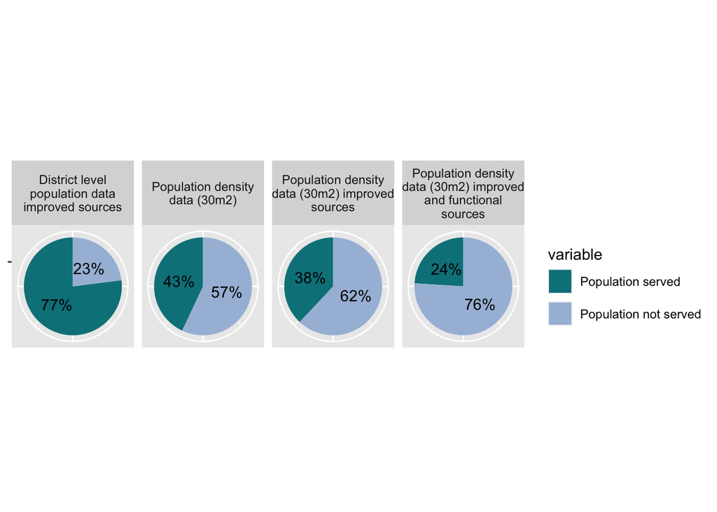